# Keras_Sequential_Model_for_Linear_Regression slides

## Import packages

- numpy - package for scientific computing with Python
- pyplot - provides a MATLAB-like plotting framework.

```python
import numpy as np
import matplotlib.pyplot as plt
```

## Import keras packages

- keras - the neural network library
- Sequential - basic keras model composed of a linear stack of layers.
- Dense - a regular densely-connected NN layer.

```python
import keras
from keras.models import Sequential
from keras.layers import Dense
```

## Define a linear regression problem

```python
train_data_X = np.linspace(-1, 1, 101)
train_data_Y = 4 * train_data_X + np.random.randn(101) * 0.44
```

```python
train_data_X
```

```
array([-1.  , -0.98, -0.96, -0.94, -0.92, -0.9 , -0.88, -0.86, -0.84,
       -0.82, -0.8 , -0.78, -0.76, -0.74, -0.72, -0.7 , -0.68, -0.66,
       -0.64, -0.62, -0.6 , -0.58, -0.56, -0.54, -0.52, -0.5 , -0.48,
       -0.46, -0.44, -0.42, -0.4 , -0.38, -0.36, -0.34, -0.32, -0.3 ,
       -0.28, -0.26, -0.24, -0.22, -0.2 , -0.18, -0.16, -0.14, -0.12,
       -0.1 , -0.08, -0.06, -0.04, -0.02,  0.  ,  0.02,  0.04,  0.06,
        0.08,  0.1 ,  0.12,  0.14,  0.16,  0.18,  0.2 ,  0.22,  0.24,
        0.26,  0.28,  0.3 ,  0.32,  0.34,  0.36,  0.38,  0.4 ,  0.42,
        0.44,  0.46,  0.48,  0.5 ,  0.52,  0.54,  0.56,  0.58,  0.6 ,
        0.62,  0.64,  0.66,  0.68,  0.7 ,  0.72,  0.74,  0.76,  0.78,
        0.8 ,  0.82,  0.84,  0.86,  0.88,  0.9 ,  0.92,  0.94,  0.96,
        0.98,  1.  ])
```

```python
train_data_Y
```

```
array([-4.17079833, -3.87634885, -3.53599357, -3.30792173, -3.99486578,
       -3.06492874, -4.25012946, -3.6815994 , -3.09358573, -2.8464002 ,
       -2.59688395, -3.21388018, -3.17944785, -3.0064456 , -3.14280531,
       -3.40564822, -2.08521588, -2.95534929, -3.06273358, -2.84951963,
       -1.77739337, -3.2817135 , -2.82901742, -2.00348643, -2.12070433,
       -1.82633051, -1.69028555, -2.35392167, -1.21597876, -2.04694174,
       -2.3600831 , -1.21120332, -1.6572161 , -0.40557911, -2.01749273,
       -1.30749546, -0.91403906, -1.00337697, -1.18585269, -0.82464271,
       -0.4956535 , -0.73319942, -0.4133427 , -0.32171572, -0.1302086 ,
       -0.38564256, -0.01426358, -0.50298794, -0.53936152,  0.71148126,
        0.16558609, -0.45948704,  0.21219291,  0.63876113, -0.13107309,
        0.04419493,  0.51646225,  0.4240881 ,  1.60462292,  0.71612593,
        0.79510072,  0.89743866,  0.44758584,  0.84244821,  1.07409986,
        1.92123789,  1.09950108,  1.2700024 ,  1.38537452,  1.08085146,
        0.94853054,  1.66913271,  1.3181715 ,  1.47526769,  1.1025451 ,
        1.4522959 ,  2.74834748,  2.30769339,  2.67258838,  2.5214474 ,
        2.456915  ,  2.28192976,  2.58080656,  1.68681444,  2.92861175,
        3.02943398,  2.50275195,  3.17801958,  3.04586795,  2.78842604,
        3.23758009,  2.96526701,  2.08660318,  2.90554821,  3.72860646,
        3.79663661,  4.17123961,  4.16463285,  4.23406848,  3.959626  ,
        3.33912502])
```

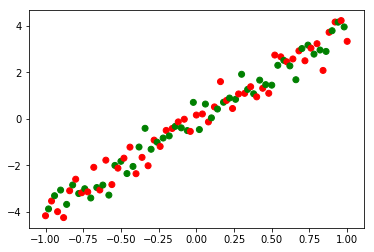

```python
plt.scatter(train_data_X, train_data_Y, label='data',color=['red','green'])
```

## Building the model

- Steps to build a keras model:
  - Define the model
  - Add layers
  - Compile the model
  - Train the model
- We create a sequential model, which is the basic model in keras.
- Only a single connection is required, so we use a Dense layer with linear activation.
- Take input x and apply weight, w, and bias, b (wx + b ) followed by a linear activation to produce output.
- Train the weights for 200 epochs. The value of weights should become 4.
- Define mean squared error(mse) as the loss with simple gradient descent(sgd) as the optimizer.
- get_weights() : returns the weights of the layer as a list of Numpy arrays.
- summary() : prints a summary representation of your model.

```python
model = Sequential()
```

[output not shown]

```python
model.add(Dense(input_dim=1,output_dim=1, init='uniform', activation='linear'))
```

```python
# model.add(Dense(input_dim=1, name='Layer_1', output_dim=1, init='uniform', activation='linear'))
```

```python
model.summary()
```

```
_________________________________________________________________
Layer (type)                 Output Shape              Param #
=================================================================
dense_1 (Dense)              (None, 1)                 2
=================================================================
Total params: 2
Trainable params: 2
Non-trainable params: 0
_________________________________________________________________
```

```python
len(model.layers)
```

```
1
```

```python
weights = model.layers[0].get_weights()
```

[output not shown]

```python
len(weights)
```

```
2
```

```python
weights
```

```
[array([[-0.04596726]], dtype=float32), array([0.], dtype=float32)]
```

```python
weight_initial = weights[0]
```

```python
bias_initial = weights[1]
```

```python
print('Linear regression model is initialized with weights w: %.2f, b: %.2f' % (weight_initial, bias_initial))
```

```
Linear regression model is initialized with weights w: -0.05, b: 0.00
```

```python
model.compile(optimizer='sgd', loss='mse')
```

[output not shown]

```python
model.fit(train_data_X, train_data_Y, epochs=200, verbose=1)
```

```
<keras.callbacks.History at 0x12bbd56d8>
```

```python
weights = model.layers[0].get_weights()
```

```python
weight_final = weights[0]
```

```python
bias_final = weights[1]
```

```python
print('Linear regression model is trained to have weight w: %.2f, b: %.2f' % (weight_final, bias_final))
```

```
Linear regression model is trained to have weight w: 3.91, b: -0.04
```

## Test the model

- predict() - Generates output predictions for the input samples.
- result will be weight_final * train_data_X + bias_final
- plot the regression line.

```python
result = model.predict(train_data_X)
```

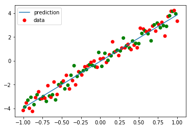

```python
plt.scatter(train_data_X, train_data_Y, label='data',color=['red','green'])
plt.plot(train_data_X, result, label='prediction')
plt.legend()
plt.show()
```